# Statistical Inference Course Project

Daren Thomas

17 September 2016

## Part 1: Simulation Excercise

In this project, I investigate the exponential distribution in R and compare it with the Central Limit Theorem. Let’s start with a sample of the exponential distribution:

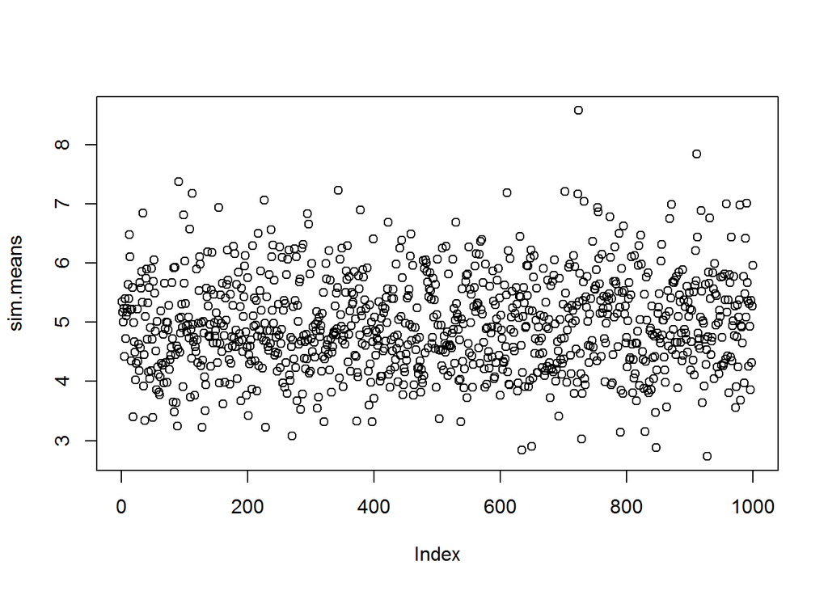

```r
n <- 40  # size of each averaging operation
sim.count <- 1000  # number of averaging operations
lambda <- 0.2
sim.means <- apply(replicate(sim.count, rexp(n, lambda)), 2, mean)
plot(sim.means)
```

Nice! Can you see a pattern? I can’t! We should do some statistics…

### Question 1: Sample mean and theoretical mean

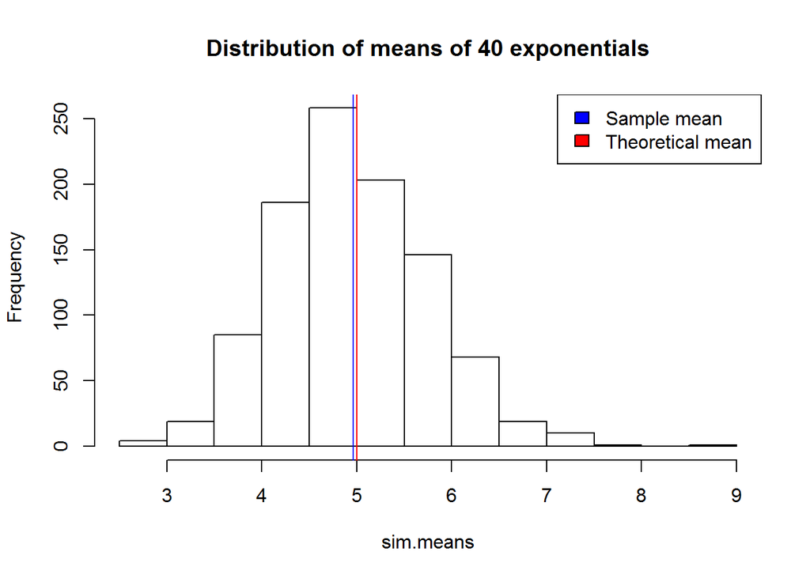

```r
hist(sim.means, main = 'Distribution of means of 40 exponentials')
sample.mean <- mean(sim.means)
theoretical.mean <- 1/lambda

abline(v=sample.mean, col='blue')
abline(v=theoretical.mean, col='red')
legend("topright", c("Sample mean", "Theoretical mean"), fill=c("blue", "red"))
```

The sample mean is 4.9616831 and the theoretical mean is 5. The difference is 0.0383169. I use the mean of the exponential distribution as the mean of the distribution of the means because CLM states I can.

### Question 2: Variance of sample vs. theoretical variance

The CLM states that the averages are approximately normal, with distributions centered at the population mean and with standard deviation equal to the standard error of the mean. The CLM states that the means shoudl follow a standard normal distribution “N(mu/s^2/n)”. Therefore the theoretical variance is s^2/n. We know s to be 1/lambda, so:

```r
# sample variance (of the means)
sim.means.var <- var(sim.means)
print(sim.means.var)
```

```
## [1] 0.6408254
```

```r
# theoretical variance (according to CLM)
theoretical.sd <- 1/lambda / sqrt(n)
theoretical.var <- theoretical.sd^2
print(theoretical.var)
```

```
## [1] 0.625
```

The sample variance is 0.6408254 and the theoretical variance is 0.625 - the difference is 0.0158254.

### Question 3: The distribution is approximately normal

Based on the CLM, the distribution of the of the simulated means should approximate a normal distribution with mean 5 and variance 0.625. Let’s just plot such a distribution over our histogram:

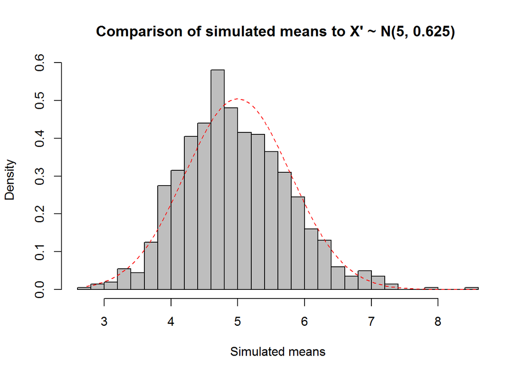

```r
# plot simulated means
hist(sim.means, breaks = 40, freq=FALSE, xlab = "Simulated means", main = "Comparison of simulated means to X' ~ N(5, 0.625) ", col = "grey")

# plot the theoretical distribution
x <- seq(min(sim.means), max(sim.means), length = 100)
y <- dnorm(x, mean = theoretical.mean, theoretical.sd)
lines(x, y, lty=2, col='red')
```

The plot shows how the density of the simulated means follows the expected normal distribution quite closely.